# Cluster-Based Relative Value Strategy: Intra-Cluster Mean Reversion on SPDR Sector ETFs

Author

Mathew Frame

Published

April 7, 2026

## 1. Intuitive Rationale

### Strategy Thesis

This strategy tests one hypothesis: that sector ETFs temporarily deviate from their co-moving peers and that those deviations are more likely to revert than persist. The mechanism being tested is whether unsupervised clustering on rolling return correlations can identify which ETFs genuinely move together, and whether overweighting the recent underperformer within each group generates risk-adjusted returns above a passive SPY benchmark. This project does not assume the hypothesis is correct. It tests it honestly, with full acknowledgment of where and why it fails.

### What Clustering Adds

A naive mean-reversion strategy would buy any ETF that has dropped recently. The problem is that not all ETFs are comparable: buying XLE because it underperformed XLK assumes those two sectors share a common driver, which they often do not. Clustering first identifies which ETFs are genuinely co-moving in the current market environment, based on 60 days of rolling return correlations. Only within those empirically identified peer groups does the mean-reversion signal have a structural basis. The cluster membership itself is dynamic: it updates monthly as correlations shift, so the strategy adapts to changing market structure rather than assuming fixed relationships.

### Why the Kalman Filter Is Required

Within-cluster underperformance can have two causes: temporary noise (the ETF will revert) or a genuine trend (the ETF is repricing to a new level). Buying into a downtrend on the assumption it will revert is the single largest failure mode of mean-reversion strategies. The Kalman Filter estimates the underlying trend in each ETF’s price series by smoothing out daily noise. If the smoothed slope is negative beyond a threshold, the ETF is excluded from the portfolio entirely that day, regardless of how undervalued it appears relative to its cluster. The Kalman Filter is therefore not a signal enhancer; it is a risk gate that prevents the strategy from confusing structural repricing with temporary deviation.

### When This Strategy Fails

This strategy is designed for range-bound, mean-reverting environments and will fail in two specific conditions. The first is sustained directional trends: when sectors are repricing to fundamentally new levels (the 2022 rate shock driving XLU and XLRE down for months), within-cluster underperformers continue underperforming and the mean-reversion bet loses repeatedly. The Kalman gate reduces this exposure but does not eliminate it entirely, particularly at the onset of a trend before the slope signal has confirmed direction. The second is correlation collapse: during systemic shocks (March 2020, September 2008), all 11 ETFs correlate toward 1.0, the cluster structure becomes meaningless, and within-cluster z-scores carry no information. The strategy’s cluster quality filter addresses this by disabling trading when average intra-cluster correlation falls below a minimum threshold.

### Academic Foundation

Two papers motivate the design. Ajayi (2025) demonstrates that unsupervised K-Means clustering identifies the same major market regimes as parametric Markov Switching models, validating that rolling clustering captures economically meaningful structural breaks without requiring distributional assumptions. Raju (2025) uses rolling K-Means on equity return data and finds that cluster-based signals generate statistically significant return differentials across regimes (Sharpe differential of 2 to 4 points, p < 0.01), though those results are from Indian equities where return synchronicity is higher than in U.S. markets. Morck, Yeung, and Yu (2000) show that U.S. stocks have low return synchronicity relative to emerging markets, meaning firm-specific and sector-specific variation dominates macro signals. This implies that intra-cluster dispersion in U.S. sector ETFs will be meaningful and tradeable, but that Raju’s Sharpe differentials represent an upper bound rather than a replication target.

**Pre-Pivot Analysis**

## 2. Data and Features

Universe: SPDR Sector ETFs and Benchmark

Daily adjusted close prices. Training: June 2000 to December 2024. Testing: January 2025 to March 2026.

| Ticker | Name | Role | Available From | Source |
| --- | --- | --- | --- | --- |
| SPY | SPDR S&P 500 ETF Trust | Benchmark | 2000-06-01 | Yahoo Finance via tidyquant::tq_get() |
| XLB | Materials | Traded | 2000-06-01 | Yahoo Finance via tidyquant::tq_get() |
| XLC | Communication Services | Traded | 2018-06-19 | Yahoo Finance via tidyquant::tq_get() |
| XLE | Energy | Traded | 2000-06-01 | Yahoo Finance via tidyquant::tq_get() |
| XLF | Financials | Traded | 2000-06-01 | Yahoo Finance via tidyquant::tq_get() |
| XLI | Industrials | Traded | 2000-06-01 | Yahoo Finance via tidyquant::tq_get() |
| XLK | Technology | Traded | 2000-06-01 | Yahoo Finance via tidyquant::tq_get() |
| XLP | Consumer Staples | Traded | 2000-06-01 | Yahoo Finance via tidyquant::tq_get() |
| XLRE | Real Estate | Traded | 2015-10-08 | Yahoo Finance via tidyquant::tq_get() |
| XLV | Health Care | Traded | 2000-06-01 | Yahoo Finance via tidyquant::tq_get() |
| XLU | Utilities | Traded | 2000-06-01 | Yahoo Finance via tidyquant::tq_get() |
| XLY | Consumer Discretionary | Traded | 2000-06-01 | Yahoo Finance via tidyquant::tq_get() |

XLC available from June 2018; XLRE available from October 2015. Both included despite shorter histories.

All price data is sourced via API with no local files. Log returns are computed as $r_t = \log(P_t / P_{t-1})$ on adjusted close prices, which account for dividends and splits. Log returns are used rather than simple returns because they are additive across time, approximately normally distributed, and produce a more stable correlation matrix, which is the direct input to the clustering algorithm. SPY is carried as the benchmark throughout but is never included in the traded universe or the clustering.

The clustering input is not the raw return series but the pairwise correlation matrix computed over a rolling 60-day window. Clustering directly on returns would group ETFs by recent absolute performance, crowding recent winners into one cluster regardless of whether they share underlying economic drivers. Correlation captures co-movement independent of magnitude: two ETFs are similar if they move in the same direction at the same time, not because they both went up. The 60-day window is a deliberate balance between responsiveness and stability. A shorter window (20 days) produces noisy correlations dominated by single events; a longer window (252 days) is too slow to reflect structural shifts in market relationships and would keep the portfolio anchored to stale cluster assignments. The 60-day parameter is treated as tunable and will be evaluated in the optimization section.

## 3. Clustering

### 3.1 Cluster Hypothesis

The following cluster assignments are stated before any computation is performed. Results will be assessed honestly against these priors.

Cluster Hypothesis: Expected Groupings Before Computation

Stated prior to running the elbow method or hierarchical clustering.

| Cluster | Sectors | Core Driver |
| --- | --- | --- |
| Cyclical | Industrials, Financials, Consumer Discretionary | GDP / growth |
| Defensive | Staples, Utilities, Healthcare | Stability / recession |
| Commodity | Energy, Materials | Inflation / commodities |
| Rate-Sensitive | Technology, Communication Services, Real Estate | Interest rates |

Hypothesis informed by sector economic characteristics, not by training data.

### 3.2 Selecting k: Elbow Method

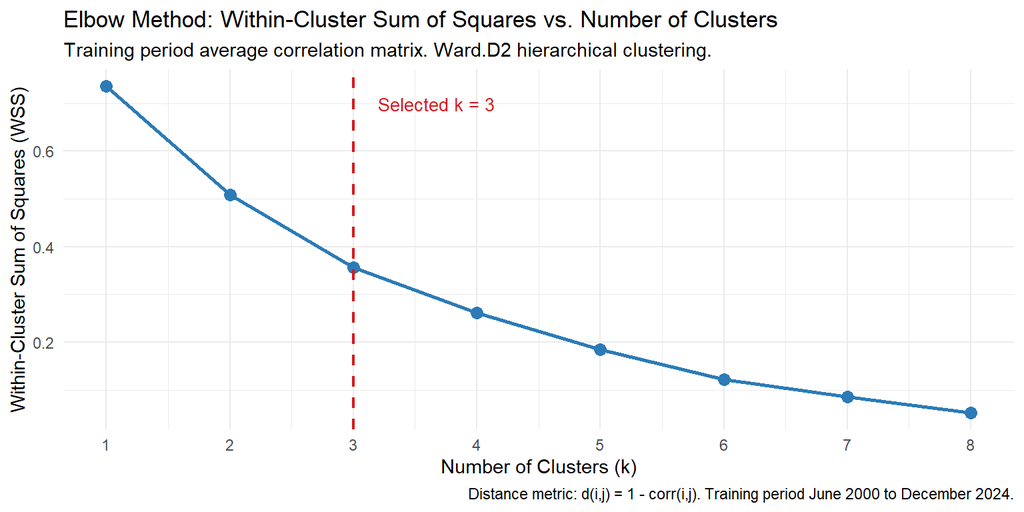

Despite my initial hypothesis being k = 4, **the elbow I see is at k = 3.** There is a meaningful reduction in WSS from 3 -> 4, but the decision to use k = 3 comes from the change in slope from 2 -> 4 having a sharper angle than 3 -> 5. There is no right answer here, but using 4 clusters creates the risk of weak clusters that change often, leading to increased transaction costs for the trading strategy.

### 3.3 Hierarchical Clustering

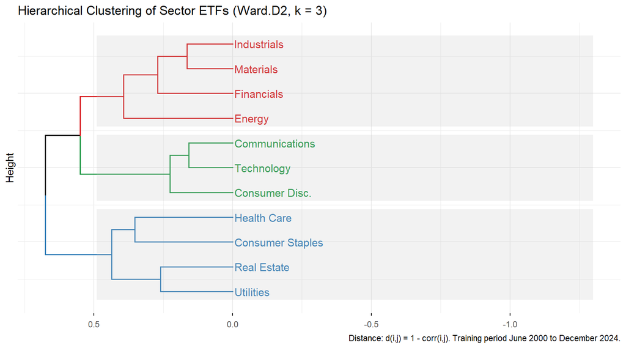

Cluster Assignments at k = 3

Average silhouette width: 0.221 (> 0.25 indicates meaningful structure)

| Cluster | ETFs | Size |
| --- | --- | --- |
| 1 | XLB, XLE, XLF, XLI | 4 |
| 2 | XLC, XLK, XLY | 3 |
| 3 | XLP, XLRE, XLU, XLV | 4 |

Assignments derived from full training period average correlation matrix.

### 3.4 Revisiting k: Testing k = 4

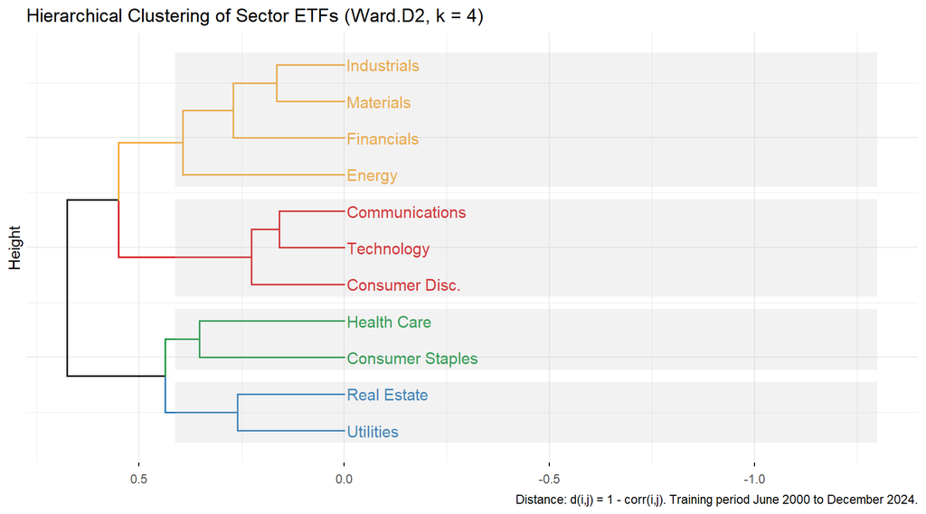

Cluster Assignments at k = 4

Average silhouette width: 0.223 (> 0.25 indicates meaningful structure)

| Cluster | ETFs | Size |
| --- | --- | --- |
| 1 | XLB, XLE, XLF, XLI | 4 |
| 2 | XLC, XLK, XLY | 3 |
| 3 | XLP, XLV | 2 |
| 4 | XLRE, XLU | 2 |

Assignments derived from full training period average correlation matrix.

### 3.5 Revisiting k: Testing k = 5

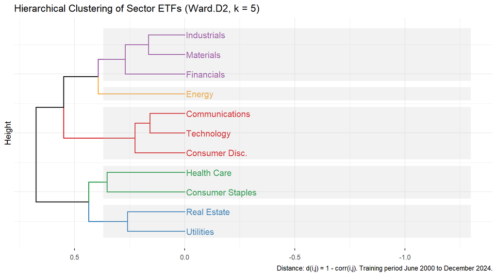

Cluster Assignments at k = 5

Average silhouette width: 0.199 (> 0.50 indicates reasonable structure)

| Cluster | ETFs | Size |
| --- | --- | --- |
| 1 | XLB, XLF, XLI | 3 |
| 2 | XLE | 1 |
| 3 | XLC, XLK, XLY | 3 |
| 4 | XLP, XLV | 2 |
| 5 | XLRE, XLU | 2 |

Assignments derived from full training period average correlation matrix.

### 3.6 Revisiting k: Testing k = 6

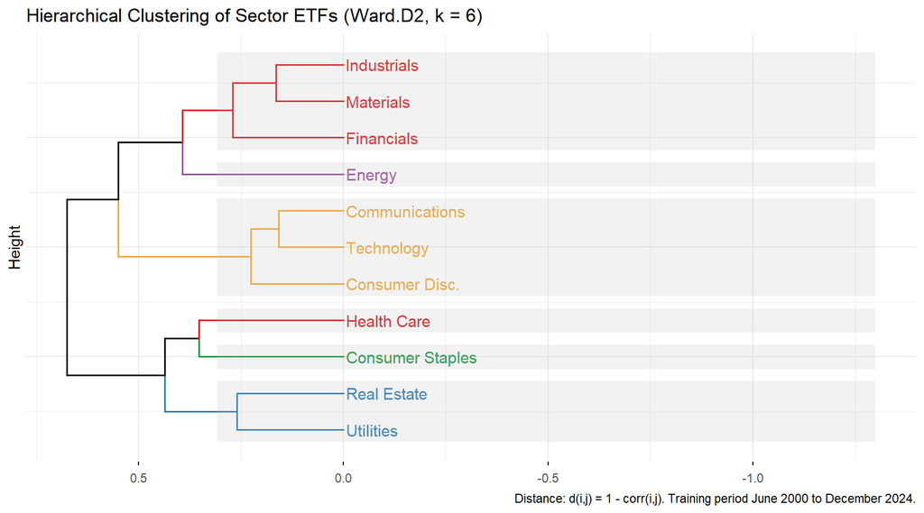

Cluster Assignments at k = 6

Average silhouette width: 0.197 (> 0.50 indicates reasonable structure)

| Cluster | ETFs | Size |
| --- | --- | --- |
| 1 | XLB, XLF, XLI | 3 |
| 2 | XLE | 1 |
| 3 | XLC, XLK, XLY | 3 |
| 4 | XLP | 1 |
| 5 | XLV | 1 |
| 6 | XLRE, XLU | 2 |

Assignments derived from full training period average correlation matrix.

### 3.7 Silhouette Comparison: k = 3 to 6

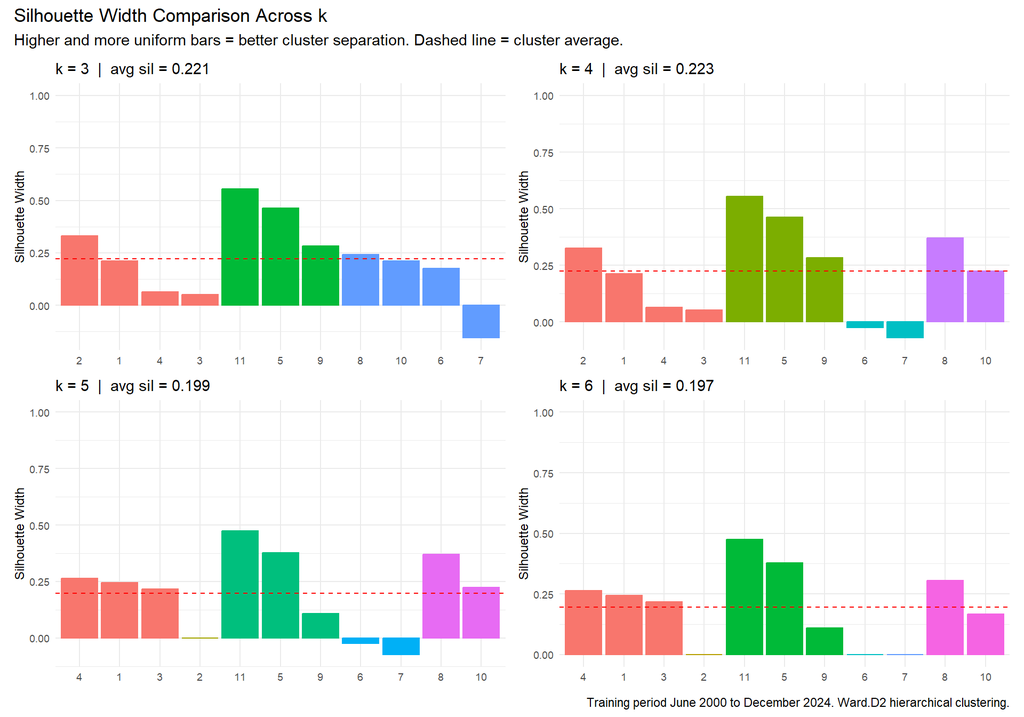

### 3.8 Cluster Stability Over Time

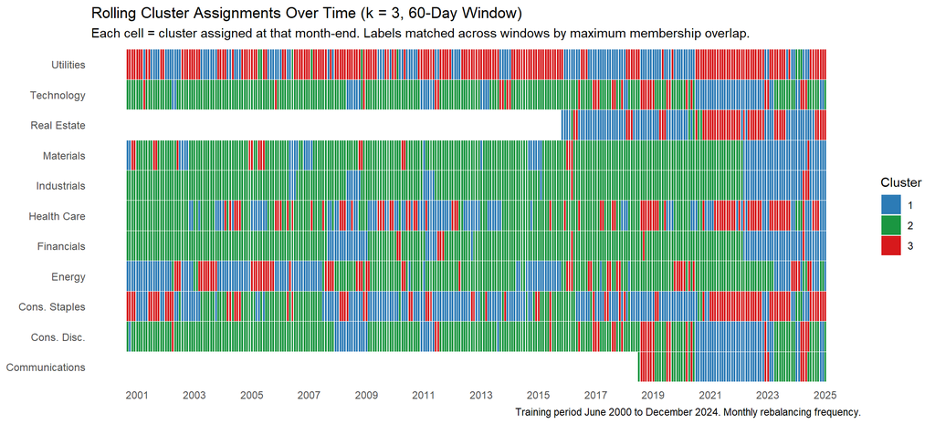

Per-ETF Cluster Persistence

Average window-to-window stability: 83.9% of ETFs unchanged each month

| Sector | Primary Cluster | Time in Primary Cluster (%) | Cluster Switches |
| --- | --- | --- | --- |
| Industrials | 2 | 82.6 | 13 |
| Financials | 2 | 77.8 | 16 |
| Materials | 2 | 74.7 | 30 |
| Cons. Disc. | 2 | 71.3 | 38 |
| Technology | 2 | 70.6 | 45 |
| Utilities | 3 | 60.1 | 60 |
| Real Estate | 1 | 56.8 | 21 |
| Energy | 2 | 50.2 | 55 |
| Cons. Staples | 1 | 48.1 | 72 |
| Communications | 1 | 44.3 | 17 |
| Health Care | 2 | 44.0 | 88 |

Modal cluster = cluster assigned most frequently over training period.

### 3.9 Pivot: Adding Rolling Volatility as a Second Feature

The instability finding above is not a reason to abandon clustering. It is a reason to enrich the feature set. Rolling return correlations capture the direction of co-movement but not the character of each ETF’s risk profile. A defensive ETF and a cyclical ETF can temporarily correlate during a broad market rally, causing the algorithm to group them together even though their structural characters are completely different. Rolling realized volatility is a structural feature that is far more persistent: Utilities and Consumer Staples are low-vol in every market environment; Energy and Technology are high-vol across regimes. Adding volatility as a second clustering input gives the algorithm a stable anchor that persists through correlation regime shifts.

The implementation combines two normalized distance matrices: the correlation distance (1 minus pairwise correlation, same as above) and a volatility distance (absolute difference in 60-day realized volatility between each ETF pair, normalized to a 0 to 1 scale). The combined distance is a 50/50 weighted average of the two, applied to the same Ward.D2 hierarchical clustering. The weight is a parameter that will be evaluated in the optimization section.

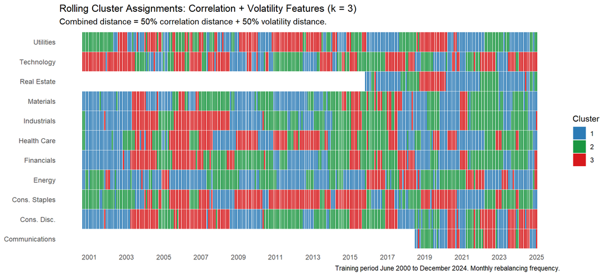

Per-ETF Cluster Persistence: Correlation + Volatility Features

Average window-to-window stability: 82.9% of ETFs unchanged each month

| Sector | Primary Cluster | Time in Primary Cluster (%) | Cluster Switches |
| --- | --- | --- | --- |
| Real Estate | 1 | 56.8 | 15 |
| Energy | 1 | 50.2 | 57 |
| Materials | 1 | 47.1 | 55 |
| Cons. Staples | 3 | 46.4 | 44 |
| Technology | 3 | 45.1 | 58 |
| Financials | 2 | 43.7 | 40 |
| Communications | 3 | 38.0 | 21 |
| Industrials | 2 | 37.9 | 35 |
| Utilities | 1 | 35.8 | 60 |
| Cons. Disc. | 3 | 34.8 | 48 |
| Health Care | 3 | 33.8 | 51 |

Compare to correlation-only table above. Improvement in pct_in_modal and fewer switches indicates feature enrichment is working.

## 2. Data and Features

Universe: SPDR Sector ETFs and Benchmark

Training: June 2000 to December 2024. Testing: January 2025 to March 2026.

| Ticker | Name | Role | Available From | Source |
| --- | --- | --- | --- | --- |
| SPY | SPDR S&P 500 ETF Trust | Benchmark | 2000-06-01 | Yahoo Finance via tidyquant::tq_get() |
| XLB | Materials | Traded | 2000-06-01 | Yahoo Finance via tidyquant::tq_get() |
| XLC | Communication Services | Traded | 2018-06-19 | Yahoo Finance via tidyquant::tq_get() |
| XLE | Energy | Traded | 2000-06-01 | Yahoo Finance via tidyquant::tq_get() |
| XLF | Financials | Traded | 2000-06-01 | Yahoo Finance via tidyquant::tq_get() |
| XLI | Industrials | Traded | 2000-06-01 | Yahoo Finance via tidyquant::tq_get() |
| XLK | Technology | Traded | 2000-06-01 | Yahoo Finance via tidyquant::tq_get() |
| XLP | Consumer Staples | Traded | 2000-06-01 | Yahoo Finance via tidyquant::tq_get() |
| XLRE | Real Estate | Traded | 2015-10-08 | Yahoo Finance via tidyquant::tq_get() |
| XLV | Health Care | Traded | 2000-06-01 | Yahoo Finance via tidyquant::tq_get() |
| XLU | Utilities | Traded | 2000-06-01 | Yahoo Finance via tidyquant::tq_get() |
| XLY | Consumer Discretionary | Traded | 2000-06-01 | Yahoo Finance via tidyquant::tq_get() |

XLC available from June 2018; XLRE from October 2015. Both included despite shorter histories.

All price data is sourced via API with no local files. Log returns are computed as $r_t = \log(P_t / P_{t-1})$ on adjusted close prices, which account for dividends and splits. The training period runs through December 2024 and is the only window used to fit any model parameter; the testing period from January 2025 onward is strictly held out. SPY is carried as the benchmark throughout but is never included in the traded universe or the clustering.

The clustering input in this revised approach is a feature matrix built from each ETF’s relationship to SPY, not pairwise correlations between sector ETFs. This addresses the core instability problem identified in the original approach: correlations between sector ETFs are highly regime-sensitive and shift sharply during stress events, causing cluster assignments to flip frequently. SPY-relative features measure each ETF’s structural character (how much it outperforms the market, how tightly it tracks it, and how it behaves during drawdowns), which are more persistent properties across market cycles. All three features share a single rolling window so the strategy has one tunable parameter rather than three independent ones.

Clustering Features: SPY-Relative Characteristics

All features computed over the same rolling window. Normalized (z-score scaled) before clustering.

| Feature | Formula | What It Captures | Rolling Window |
| --- | --- | --- | --- |
| Cumulative Excess Return | sum(r_ETF) - sum(r_SPY) over rolling window | Has this ETF been outperforming or underperforming the market recently? | Same tunable parameter (default: 60 days) |
| Beta | cov(r_ETF, r_SPY) / var(r_SPY) over rolling window | How sensitive is this ETF to broad market moves? High beta vs. defensive character. | Same tunable parameter (default: 60 days) |
| Max Drawdown Ratio | MaxDD(ETF) / MaxDD(SPY) over rolling window | Does this ETF suffer deeper drawdowns than the market? Tail risk character. | Same tunable parameter (default: 60 days) |

Features are z-score normalized before Euclidean distance is computed. Single rolling window = single optimization parameter.

Normalizing all three features before clustering is essential because they operate on different scales: excess return is a small decimal, beta is centred near 1.0, and the drawdown ratio has no natural upper bound. Z-score scaling ensures no single feature dominates the distance matrix by virtue of its units. Max Drawdown Ratio is defined as the ETF’s peak-to-trough decline divided by SPY’s peak-to-trough decline over the same window, so a ratio above 1.0 means the ETF experienced a deeper drawdown than the market, a signature of cyclical, high-beta sectors. A ratio below 1.0 indicates defensive character. This gives the algorithm a tail-risk anchor that is structurally persistent even when short-run correlations are noisy.

## 3. Clustering

### 3.1 Selecting k: Elbow Method

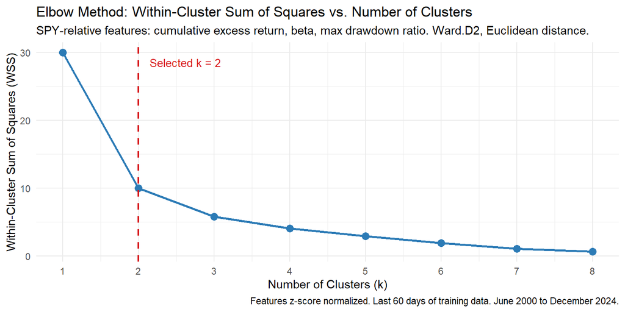

**Note for signal generation:** k = 2 produces one cluster that tracks the market closely and one that deviates from it. The deviating cluster can sit on either side of SPY: it may be the group currently outperforming the market or the group currently underperforming. The cumulative excess return feature carries the sign of that deviation, so the signal generation layer must distinguish direction within the cluster rather than assuming the “different” cluster is always the buy or always the sell.

### 3.2 Hierarchical Clustering: k = 2 vs k = 3

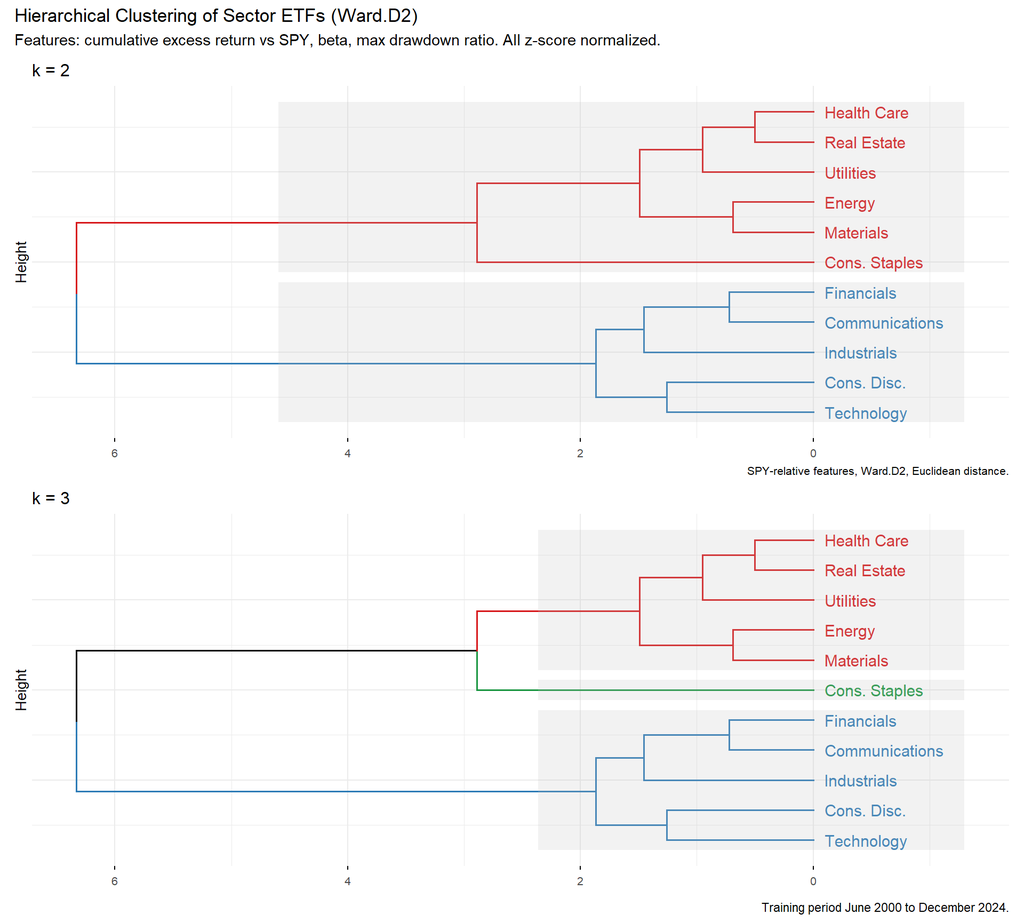

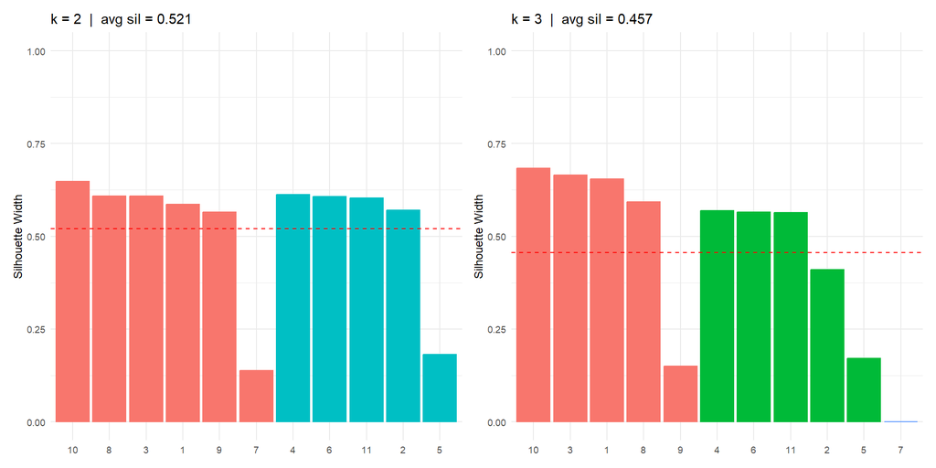

Cluster Assignments at k = 2

Average silhouette width: 0.521 (benchmark: > 0.50 is reasonable per class notes)

| Cluster | Sectors | Size |
| --- | --- | --- |
| 1 | Materials, Energy, Cons. Staples, Real Estate, Utilities, Health Care | 6 |
| 2 | Communications, Financials, Industrials, Technology, Cons. Disc. | 5 |

Assignments derived from last 60 days of training data. Labels will be revisited in rolling stability analysis.

k = 2 is confirmed. Silhouette width of 0.521 clears the 0.50 benchmark from class notes and is materially above the 0.457 achieved at k = 3. Cluster 1 groups the defensive and commodity-sensitive sectors (Materials, Energy, Consumer Staples, Real Estate, Utilities, Health Care) and Cluster 2 groups the higher-beta, growth-oriented sectors (Communications, Financials, Industrials, Technology, Consumer Discretionary). This split is economically coherent: it maps directly onto the classic defensive versus cyclical distinction that drives sector rotation in practice.

### 3.3 Cluster Stability Over Time

Rather than relying on greedy overlap matching to track labels across rolling windows, this analysis anchors labels by economic characteristic. Each month, whichever cluster has the higher mean beta is assigned the label Cyclical; the other is assigned Defensive. Beta is a structural property that is far more persistent than pairwise correlations, so this approach produces consistent labels without depending on the arbitrary order that `hclust` assigns cluster numbers.

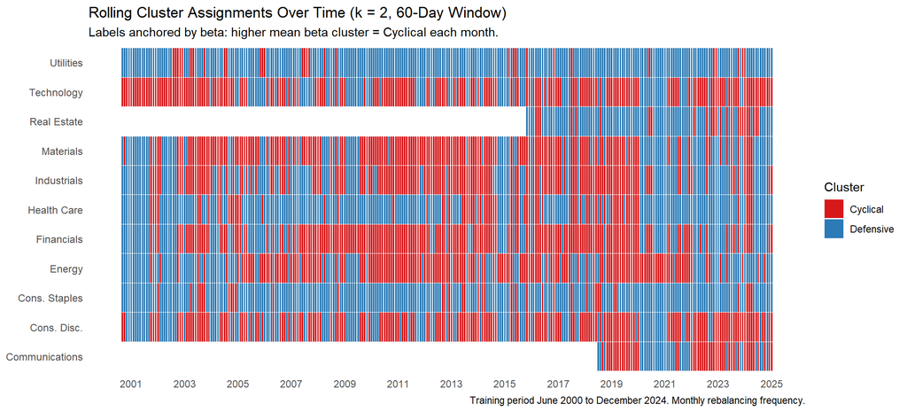

Per-ETF Cluster Persistence (k = 2, Beta-Anchored Labels)

Average window-to-window stability: 77.3% of ETFs unchanged each month

| Sector | Primary Cluster | Time in Primary Cluster (%) | Cluster Switches |
| --- | --- | --- | --- |
| Utilities | Defensive | 89.4 | 34 |
| Cons. Staples | Defensive | 87.4 | 44 |
| Real Estate | Defensive | 77.5 | 26 |
| Health Care | Defensive | 75.1 | 60 |
| Technology | Cyclical | 66.9 | 76 |
| Financials | Cyclical | 65.5 | 65 |
| Materials | Cyclical | 62.5 | 76 |
| Cons. Disc. | Cyclical | 62.1 | 86 |
| Communications | Cyclical | 59.5 | 19 |
| Energy | Cyclical | 58.4 | 80 |
| Industrials | Cyclical | 56.0 | 73 |

Modal cluster = label assigned most frequently over training period. Defensive = blue, Cyclical = red.

This approach is a material improvement over the correlation-only method used before the pivot. Three differences stand out. First, **silhouette width increased from roughly 0.22 to 0.521,** clearing the 0.50 benchmark from class notes. The clusters are no longer borderline arbitrary; the SPY-relative features produce groups that are meaningfully separated in feature space.

Second, the cluster assignments are economically coherent in a way the previous version was not. **Utilities and Consumer Staples sit in the Defensive cluster 89% and 87% of the time respectively,** which is exactly what market fundamentals predict: these are low-beta, stable-cash-flow sectors that behave defensively regardless of the macro environment. Technology and Financials anchor the Cyclical cluster, consistent with their higher market sensitivity.